# Normal Distribution, QQ Plots

Day 22

Claire Kelling

Carleton College  
STAT 120 - Fall 2026

## Question of the Day

What’s your alarm strategy in the morning? Snooze? One alarm/multiple alarms?

## Today’s Topics

Logistics:

- Metal vs electronic: A metal flipper band sticks out from the flipper, which probably makes swimming harder. An electronic tag is implanted under the skin, so it doesn’t change how the bird moves through the water.
- Talk today in Weitz! 4pm in the Perlman Teaching Museum
- How to upload data into Maize
- Resubmission of proposals, office hours after class!
- Homework 8 due today
- EDA due Wednesday!

Topics covered today:

- Paired Data
- QQ Plots

# Paired Data

## Paired Data

**Definition**

Data are **paired** if the data being compared consists of connected (paired) data values

Common Examples:

- Two measurements on each case
- Natural pairs (twins, spouses, etc)

We can use paired data to reduce natural variation in the response when comparing the two groups/treatments

- Comparing group 1 and 2 responses among similar individuals
- Reduces the effects of confounding variables
- Reduces the SE for the mean difference!

## Analyzing Paired Data

**Analysis**

Look at the difference between responses for each unit (pair)

$$d_i = x_{1,i} - x_{2,i}$$

We then analyze **the average of differences** rather than the difference of means between two groups

sample mean difference: $\bar{d}$  
sample SD of difference: $s_d$  
population mean difference: $\mu_d$

Use **one sample** inference methods for these differences

## Tuition Example

- How much higher is non-resident tuition, on average, compared to resident tuition?
- Use the Tuition2006.csv lab manual data
- The variable Diff computes the difference Res - NonRes

## Tuition Example

- Smaller sample size (n=19) and slightly left-skewed distribution
- (Or roughly symmetric with one low case!)

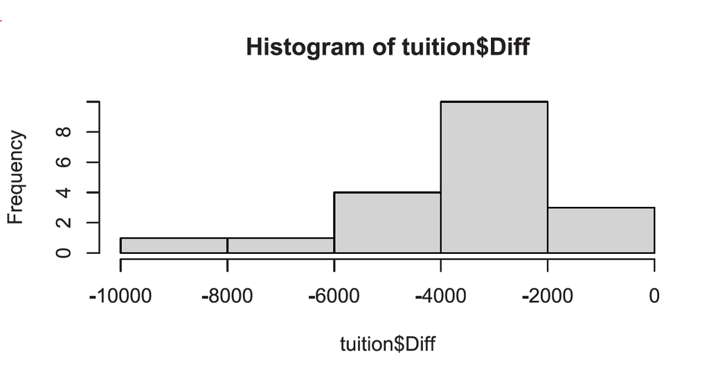

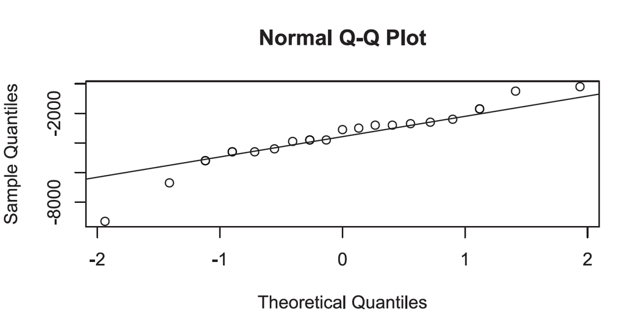

```r
hist(tuition$Diff)
qqnorm(tuition$Diff); qqline(tuition$Diff)
```

## Tuition Example

- We conduct a **one-sample** t-test on the differences.
- We are 95% confident that the mean tuition for non-residents is $2,585 to $4,584 higher than mean tuition for residents.

```r
t.test(tuition$Diff)
```

```
    One Sample t-test

data:  tuition$Diff
t = -7.5349, df = 18, p-value = 5.69e-07
alternative hypothesis: true mean is not equal to 0
95 percent confidence interval:
 -4583.580 -2584.841
sample estimates:
mean of x
-3584.211
```

```r
sd(tuition$Diff)/sqrt(19) # SE for mean diff
```

```
[1] 475.6813
```

## R Example 1

In your groups (1 RStudio open per group), work through  
Example 1 in Day 22 Handout. You can use R as a calculator!

# QQ Plots

## Normal QQ Plot

**Normal Quantile-Quantile (QQ) plot**: matches up observed quantiles (percentiles) from a sample variable to the quantiles you would expect if the variable followed a normal distribution.

- If the variable is roughly normally distributed then these quantile points should roughly follow a straight line.

General trends in QQ plots:

- Right skewed data: concave up QQ plot
- Left skewed data: concave down QQ plot
- Symmetric but more or less variable than normal:  
  S-shaped QQ plot

## Examples

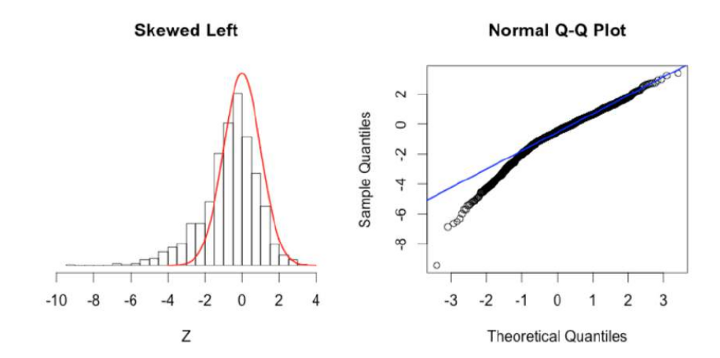

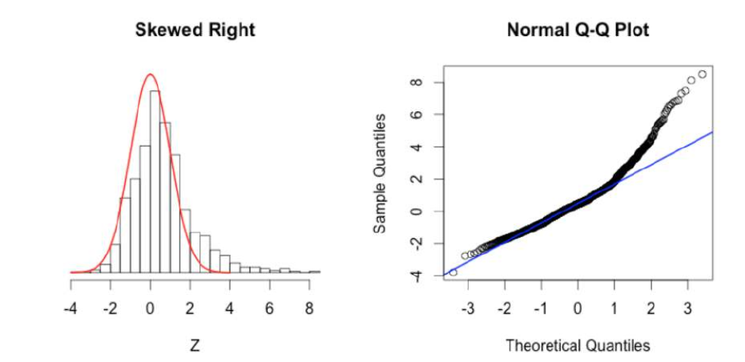

[Source: Towards Data Science](https://towardsdatascience.com/q-q-plots-explained-5aa8495426c0)

## Simulation: Normal QQ plots

Population from last class: very right skewed

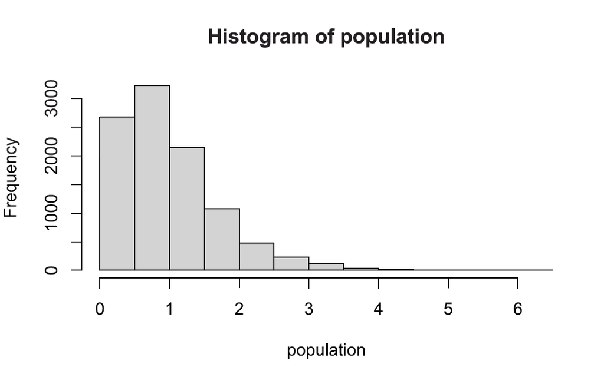

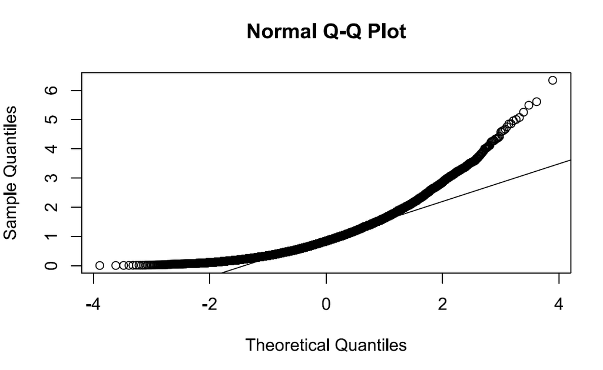

- **Left Tail**: Left tail is shorter than what we would expect for a normal distribution
  - QQ plot: left tail sample quantiles are higher than the line which is (in theory) where they should be if the sample was normally distributed
- **Right Tail**: Right tail is longer than expected under a norm dist

## Simulation: Normal QQ plots

Sampling Distribution (n=10): Some right skew

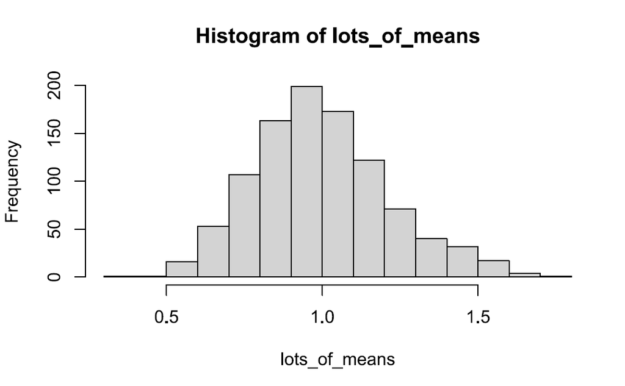

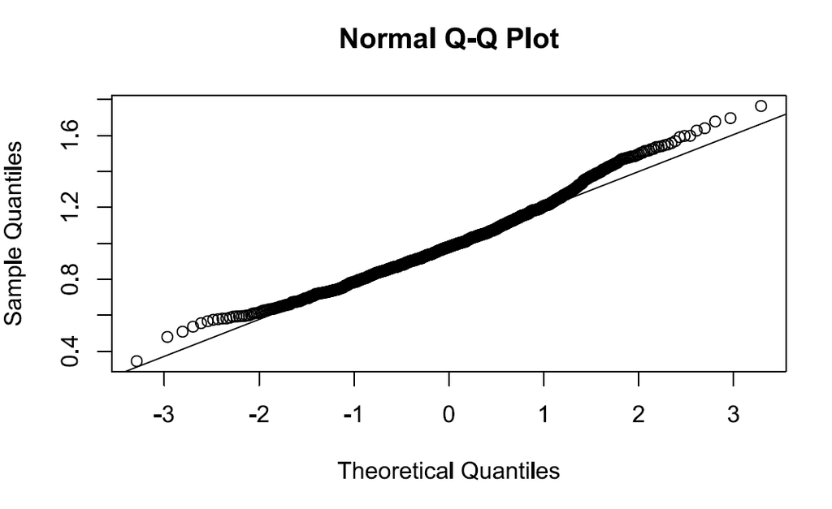

## Simulation: Normal QQ plots

Sampling Distribution (n=50): Approximately normal

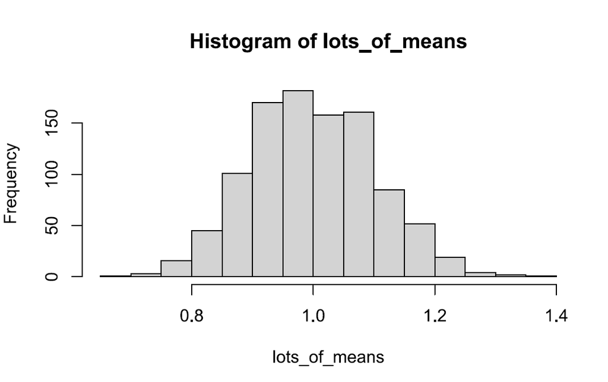

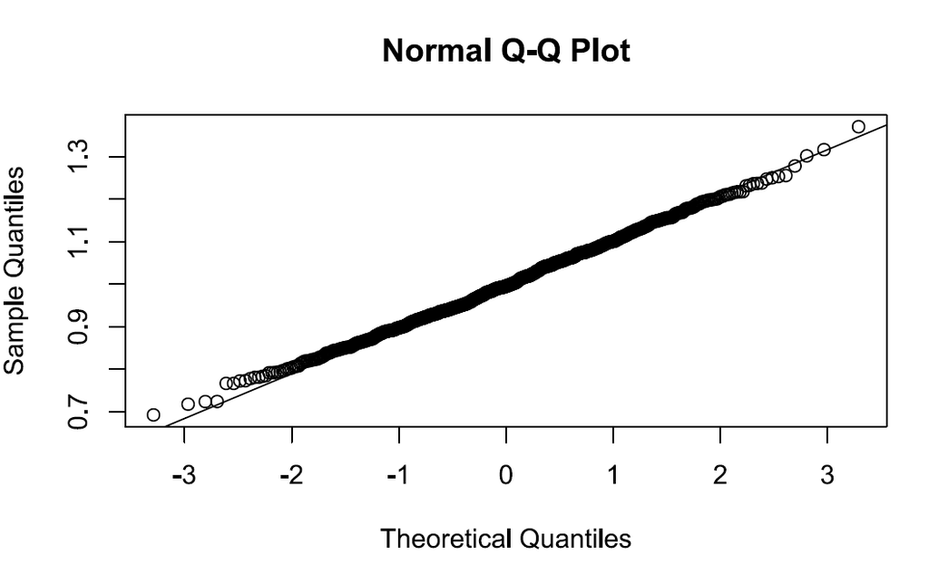

## Normal QQ plots in R

**R Code**

Base-R Plot:

```r
qqnorm(my_data$variable)
qqline(my_data$variable)
```

ggplot2 Plot:

```r
ggplot(my_data, aes(sample = variable)) + geom_qq() +
        geom_qq_line()
```

ggplot2 Plot: two samples

```r
ggplot(my_data, aes(sample = variable)) + geom_qq() +
        geom_qq_line() + facet_wrap(~cat_variable)
```

## R Example 2

In your groups (1 RStudio open per group), work through  
Example 2 in Day 22 R Handout. There is R code on Moodle!

## Next Class

Details on $\chi^2$ (new distribution!) and p-value calculation